# Exploratory Report

Cheyret Wood

Mar 03, 2022

```r
rm(list=ls())
options(stringsAsFactors=FALSE)
`%notin%` <- Negate(`%in%`)

library(tidyverse)
library(arsenal)
library(DESeq2)
library(EDASeq)
library(biomaRt)
library(ggrepel)
library(knitr)
library(kableExtra)
library(pheatmap)
library(cowplot)

load("dataProcessed/clin_cntsForAnalysis.Rdata") #clin, set
load("dataProcessed/clin_cntsForAnalysis_noGDM.Rdata") #clin_noGDM, set_noGDM
```

## Background

The purpose of this report to explore the gene expression of the subject in relation to their clinical sex, IE does the predicted sex from the gene expression match the clinical sex.

```r
# create deseq2 objects to pull out some normalized counts and unnormalized counts
dds <- DESeqDataSetFromMatrix(countData = counts(set_noGDM), colData = pData(set_noGDM),
                              design = ~ as.factor(infant_sex) + as.numeric(pre_preg_bmi))

norm_counts <- assay(vst(dds, blind = FALSE))
counts <- counts(set_noGDM)
```

```r
# add gene names
#ensembl_dec2016 <- useMart(host = 'http://dec2016.archive.ensembl.org/',
#                           biomart = 'ENSEMBL_MART_ENSEMBL',
#                           dataset = "hsapiens_gene_ensembl")

ensembl <- useMart(biomart = 'ENSEMBL_MART_ENSEMBL', dataset = "hsapiens_gene_ensembl")
key <- getBM(attributes = c("ensembl_gene_id", "external_gene_name", "chromosome_name", "gene_biotype"),
             filters = "ensembl_gene_id", values = rownames(counts(set_noGDM)), mart = ensembl)

colnames(key) <- c("geneID", "geneName", "chr_num", "gene_biotype")

protein_dat <- read.table("dataRaw/Ensembl.humanGenes.GRCh38.p7.txt",sep="\t",header=TRUE, quote = "") # originally at /home/smiharry/LEAD/dataraw_HS/k_boyle/rnaseq/Ensembl.humanGenes.GRCh38.p7.txt

protein_dat_filter <- protein_dat[,c("Gene.stable.ID","Gene.description","Chromosome.scaffold.name","Gene.start..bp.","Strand", "Gene.name", "Gene.type")]
protein_names <- unique(protein_dat_filter$Gene.stable.ID)

#length(protein_names[protein_names %in% rownames(counts(set_noGDM))])
#dim(key %>% filter(gene_biotype == "protein_coding"))

# I'm moving forward with the key defined protein_coding
#key %>% ggplot(aes(x = chr_num)) + geom_histogram(stat = "count") + theme_bw() + labs(x = "Chromosome Number", title = "Number of Genes at Each Chromosome")
#key %>% group_by(gene_biotype) %>% tally(sort = T) %>% kable(caption = "Number of Genes in Each Ensembl Gene Biotype")%>% kable_styling(full_width = FALSE)
```

## PCA Analysis

PCA analysis was completed used the built in functions in DESeq2, namely plotPCA(). This function was used with gene counts with variance stabilizing transformation (VST) applied, the group of interest was infant sex (intgroup), and all other options were set at defaults.

**PCA Plot of All Genes**

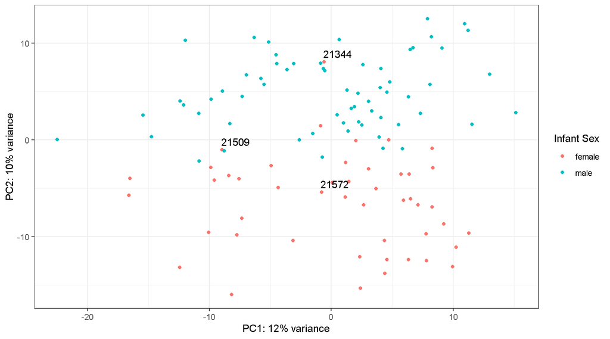

```r
pca_all <- plotPCA(vst(dds), intgroup = "infant_sex", returnData = TRUE)
pca_all$PID <- sub('.', '', pca_all$name)
pca_all$infant_sex <- ifelse(pca_all$infant_sex == "2", "male", "female")
percentVarA <- round(100 * attr(pca_all, "percentVar"))

qplot(PC1, PC2, color = infant_sex, data = pca_all) + theme_bw() +
  geom_text_repel(data = subset(pca_all, subset = PID %in% c("21509", "21572","21344")), aes(label = PID), color = "black") +
  labs(x = paste0("PC1: ",percentVarA[1],"% variance"), y = paste0("PC2: ",percentVarA[2],"% variance"), color = "Infant Sex")
```

From the plot above PC2 separates the subjects by infant sex fairly well. Our three subjects of interest labeled, 21344 is grouped with the male subjects, 21509 is closer to the male group then the female group, and 21572 is in the female group. There are though a few female and male subjects in that middle area that could go either way.

### Genes on the Sex Chromosomes

To continue looking at this possible misidentified sex the genes located on the sex chromosome will be looked at. Starting with just looking at the genes on the Y chromosome exclusively. In Ensembl, only genes unique to the Y chromosome are labeled on the Y chromosome, genes on the parts of the Y chromosome that are analogous to the X chromosome are included only on the X chromosome.

#### Y Chromosome

There are 14 genes on the Y chromosome, of these 9 are protein coding.

**Unnormalized Gene Expression for Genes on the Y Chromosome**

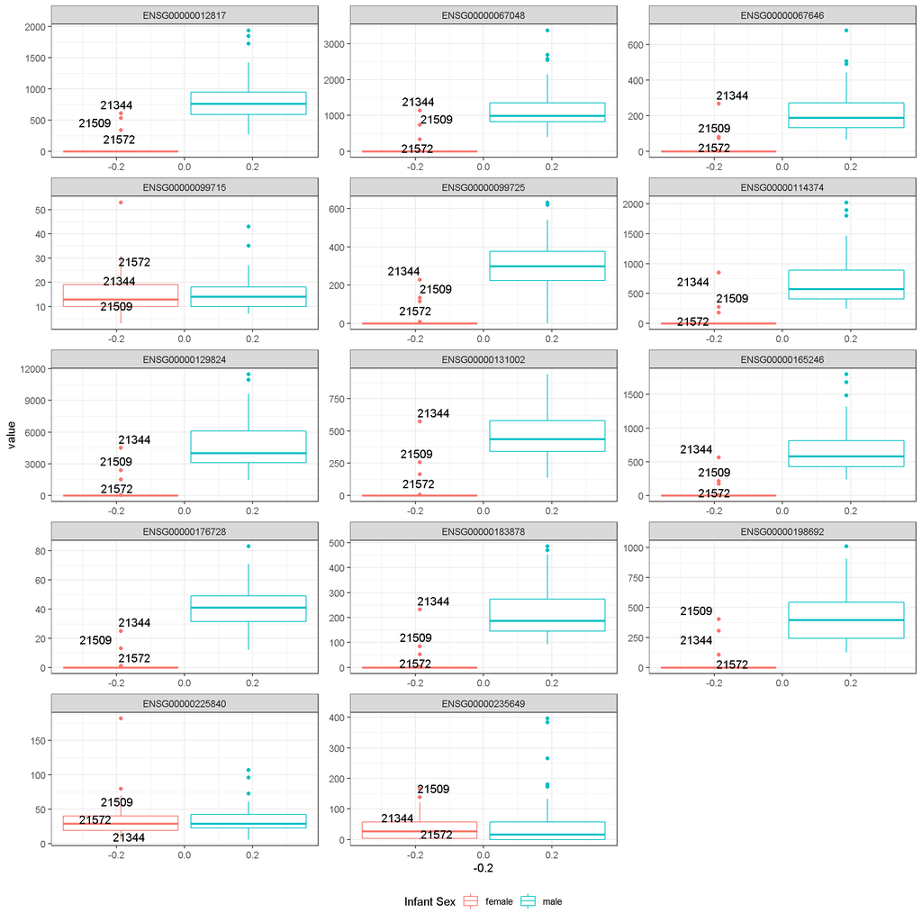

```r
# find the ids for clinical male subjects
counts_y <- counts[key$geneID[which(key$chr_num == "Y")],]
counts_y.long <- as.data.frame(t(counts_y))
counts_y.long$PID <- sub('.', '', rownames(counts_y.long))
counts_y.long <- merge(counts_y.long, clin_noGDM, by = "PID")
counts_y.long <- reshape2::melt(counts_y.long, id.vars = colnames(clin_noGDM))
counts_y.long$infant_sex <- ifelse(counts_y.long$infant_sex == "2", "male", "female")
#counts_y.long %>% ggplot(aes(y = value, x = PFHXS_ng_ml, color = infant_sex)) + geom_point() + facet_wrap(~variable, scales = "free") + theme_bw()+ geom_text_repel(data = subset(counts_y.long, subset = infant_sex == "1" & value > 50), aes(label = PID), color = "black")

counts_y.long %>%
  #mutate(label = ifelse(variable %in% key$geneID[which(key$gene_biotype=="protein_coding")], paste0(variable, "*"), paste0(variable, ""))) %>%
  ggplot(aes(y = value, color = infant_sex)) + geom_boxplot() + theme_bw() + labs(color = "Infant Sex") +
  theme(legend.position = "bottom") +
  geom_text_repel(data = subset(counts_y.long, subset = PID %in% c("21509", "21572","21344")),
                  aes(label = PID, y = value, x = -0.2), color = "black")+ facet_wrap(~variable, scales = "free", ncol = 3)
```

```r
counts_sex <- norm_counts[key$geneID[which(key$chr_num %in% c("Y", "X") & key$gene_biotype == "protein_coding")],]

sex_genes <- key$geneID[which(key$chr_num %in% c("Y", "X"))]
sex_pro_genes <- key$geneID[which(key$chr_num %in% c("Y", "X") & key$gene_biotype == "protein_coding")]
#summary(key[which(key$chr_num == c("Y", "X")),] %>% mutate_all(funs(as.factor(.))))
#summary(key[which(key$chr_num %in% c("Y", "X")),] %>% mutate_all(funs(as.factor(.))))
```

```r
y_genes <- key$geneID[which(key$chr_num == "Y")]
y_pro_genes <- key$geneID[which(key$chr_num ==  "Y" & key$gene_biotype == "protein_coding")]
```

##### PCA Plot

All Y genes will be included in the PCA plot below. Although given how few genes are included in the PCA analysis, these results are at risk of being unstable, so no conclusions can really be made.

**PCA Plot of Genes on the Y Chromosome**

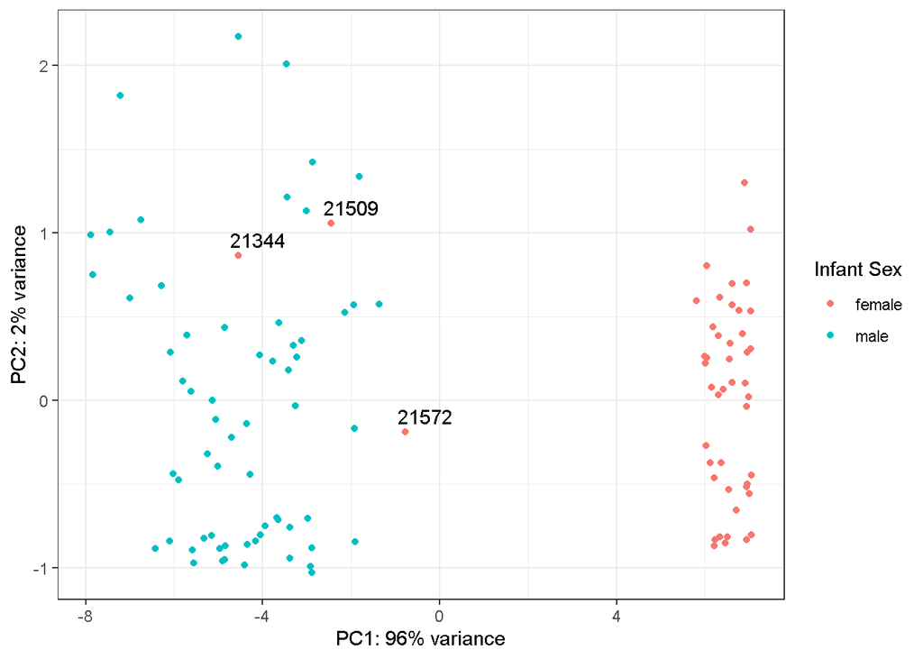

```r
pca_y <- plotPCA(subset(vst(dds), subset = rownames(vst(dds)) %in% y_genes), intgroup = "infant_sex", returnData = TRUE)
pca_y$PID <- sub('.', '', pca_y$name)
pca_y$infant_sex <- ifelse(pca_y$infant_sex == "2", "male", "female")
percentVar <- round(100 * attr(pca_y, "percentVar"))

qplot(PC1, PC2, color = infant_sex, data = pca_y) + theme_bw() +
  geom_text_repel(data = subset(pca_y, subset = PID %in% c("21509", "21572","21344")), aes(label = PID), color = "black") +
  labs(x = paste0("PC1: ",percentVar[1],"% variance"), y = paste0("PC2: ",percentVar[2],"% variance"), color = "Infant Sex")
```

Subjects 21344, 21509, and 21572 are female subjects grouped with the male subjects in the plot above.

```r
norm_counts_y <- norm_counts[key$geneID[which(key$chr_num == "Y")],]
clin$PID_x <- paste0("X",clin$PID)
clin <- clin %>% filter(PID_x %in% colnames(norm_counts_y))
identical(colnames(norm_counts_y), clin$PID_x)
norm_counts_y <- norm_counts_y[,match(clin$PID_x, colnames(norm_counts_y))]
identical(colnames(norm_counts_y), clin$PID_x)

for(i in 1:nrow(norm_counts_y)){
  fit <- lm(norm_counts_y)
}
```

```r
x_genes <- key$geneID[which(key$chr_num == "X")]
x_pro_genes <- key$geneID[which(key$chr_num ==  "X" & key$gene_biotype == "protein_coding")]
```

#### PCA for Just X Genes

There are 510 genes on the X chromosome. Of these there are 48 that are not protein coding. All X genes will be included in the PCA plot below.

**PCA Plot of Genes on the X Chromosome**

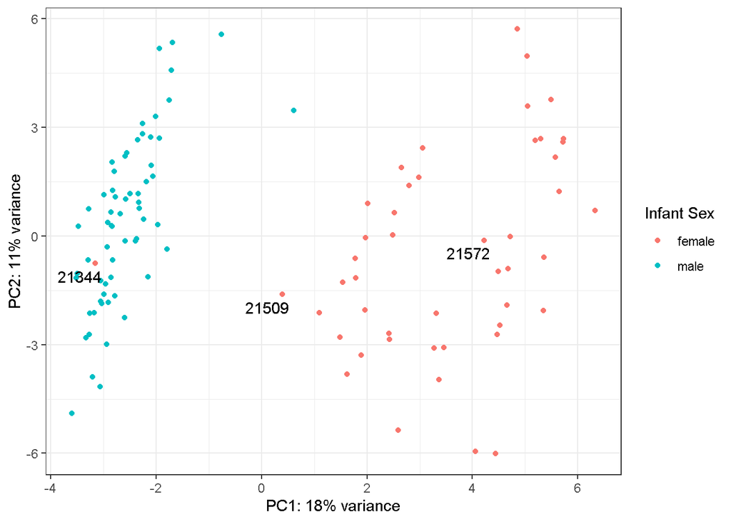

```r
pca_x <- plotPCA(subset(vst(dds), subset = rownames(vst(dds)) %in% x_genes), intgroup = "infant_sex", returnData = TRUE)
pca_x$PID <- sub('.', '', pca_x$name)
pca_x$infant_sex <- ifelse(pca_x$infant_sex == "2", "male", "female")
percentVar_x <- round(100 * attr(pca_x, "percentVar"))

qplot(PC1, PC2, color = infant_sex, data = pca_x) + theme_bw() +
  geom_text_repel(data = subset(pca_x, subset = PID %in% c("21509", "21572","21344")), aes(label = PID), color = "black") +
  labs(x = paste0("PC1: ",percentVar_x[1],"% variance"), y = paste0("PC2: ",percentVar_x[2],"% variance"), color = "Infant Sex")
```

Subjects 21572 and 21509 are female subjects grouped with the female subjects in the plot above. Subject 21344 is grouped with the male subjects.

#### PCA for All Sex Genes

There are 524 genes on the X or Y chromosome. Of these there are 53 that are not protein coding. All sex genes will be included in the PCA plot below.

**PCA Plot of Genes on the X and Y Chromosome**

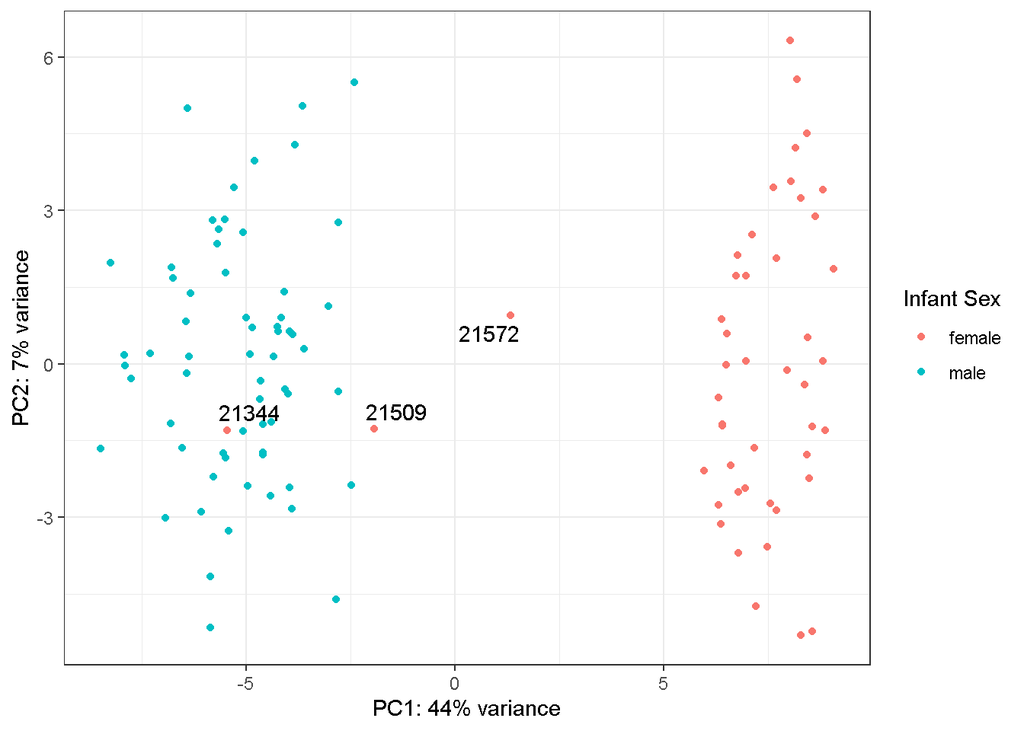

```r
pca_sex <- plotPCA(subset(vst(dds), subset = rownames(vst(dds)) %in% sex_genes), intgroup = "infant_sex", returnData = TRUE)
pca_sex$PID <- sub('.', '', pca_sex$name)
pca_sex$infant_sex <- ifelse(pca_sex$infant_sex == "2", "male", "female")
percentVar_sex <- round(100 * attr(pca_sex, "percentVar"))

qplot(PC1, PC2, color = infant_sex, data = pca_sex) + theme_bw() +
  geom_text_repel(data = subset(pca_sex, subset = PID %in% c("21509", "21572","21344")), aes(label = PID), color = "black") +
  labs(x = paste0("PC1: ",percentVar_sex[1],"% variance"), y = paste0("PC2: ",percentVar_sex[2],"% variance"), color = "Infant Sex")
```

Subjects 21344 and 21509 are female subjects grouped with the male subjects in the plot above. Subject 21572 is not grouped with either group.